# TMLE Data Summary and Wragling

Jingjing Qi

April 6, 2020; updated 2020-09-16

# Data

## Data Summary

The dataset includes 128 patients with maximum follow-up time of 51 months after discharge of LVAD implantation, 32 baseline covariates (patient characteristics and lab result), and 25 time-varying covariates (lab results and information of medication prescribed in follow-up visit). 23 patients showed event of interest (GI bleeding or mortality after discharge), 22 patients showed event of interest in the first 18 months.

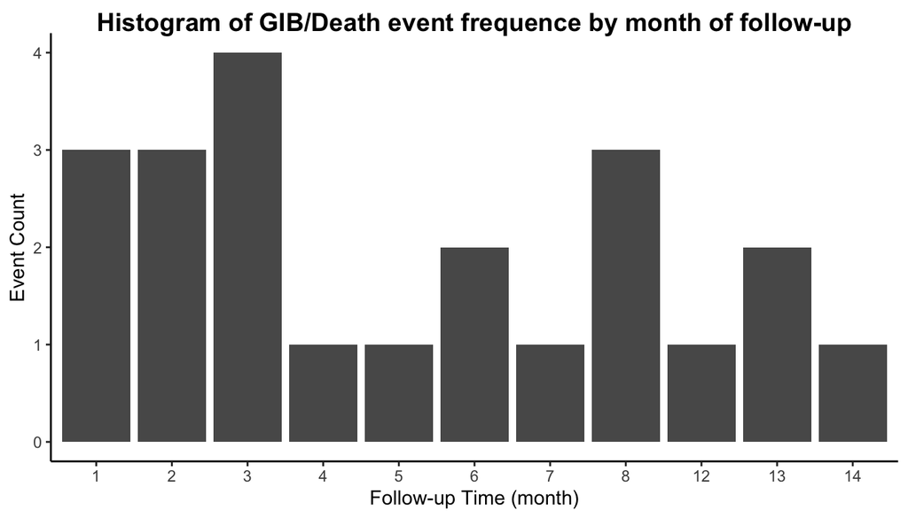

## Censoring, Time Node, Dynamic Treatment Regimes, and Time-Varying Confounders

Data collection sequence follows: $L_0$, $A_0$, $T_1$, $C_1$, $L_1$, $A_1$, $Y_1$, $C_2$,…… $C_t$, $Y_t$, where $C$ is the binary indicator of censoring, $Y$ is the binary indicator of outcome at time node $t$, $A_0$ … $A_{t-1}$ is the binary indicator of treatment exposure of medication of interest (Digoxin or Ace/Arb), $L_0$ is the baseline covariates and $L_1$ … $L_{t-1}$ are the time-varying covariates (lab results and information of medication prescribed in follow-up time node $t$). The data is also assumed to satisfy assumptions of consistency, positivity, and sequential randomization and no unmeasured confounders.

The data is right censored at 18 months after the date of discharge and summarized by time node of a 3 months duration.

Medication usage of each node is calculate by summarizing duration in days within each time node, avaliable information in dosage is in cooperated as multiplier to the duration. Lab result of each node is the average values of avaliable information in each time node.

Binary treatment indicator is evaluated by whether the cumulative time of medicine usage is >0.

# Method

## Survival Marginal Structual Model

$\lambda_{T_\overline{a}}(t|L)=\lambda_0(t)exp(\beta_1a(t)+\beta_2Cum.a)$  
where $\lambda_0(t)$ is the unspecified baseline hazard, $\lambda_{T_\overline{a}}(t|L)$ is the hazard of adverse event at time $t$ among subjects followed treatment history $\overline{a}$ through time $t$. The parameter $\beta_1$ is the causal hazard log ratio of the treatment of interest (Digoxin or Ace/Arb) at time $t$ under dynamic treatment regimes. $\beta_2$ is the causal hazard log ratio of the cumulative Digoxin treatment time $Cum.a$, which is the summarized variable of the empirical treatment regimens observed in the dataset.

# Result

## Digoxin 18-month censoring / 3-month node

### Digoxin Treatment Timeline

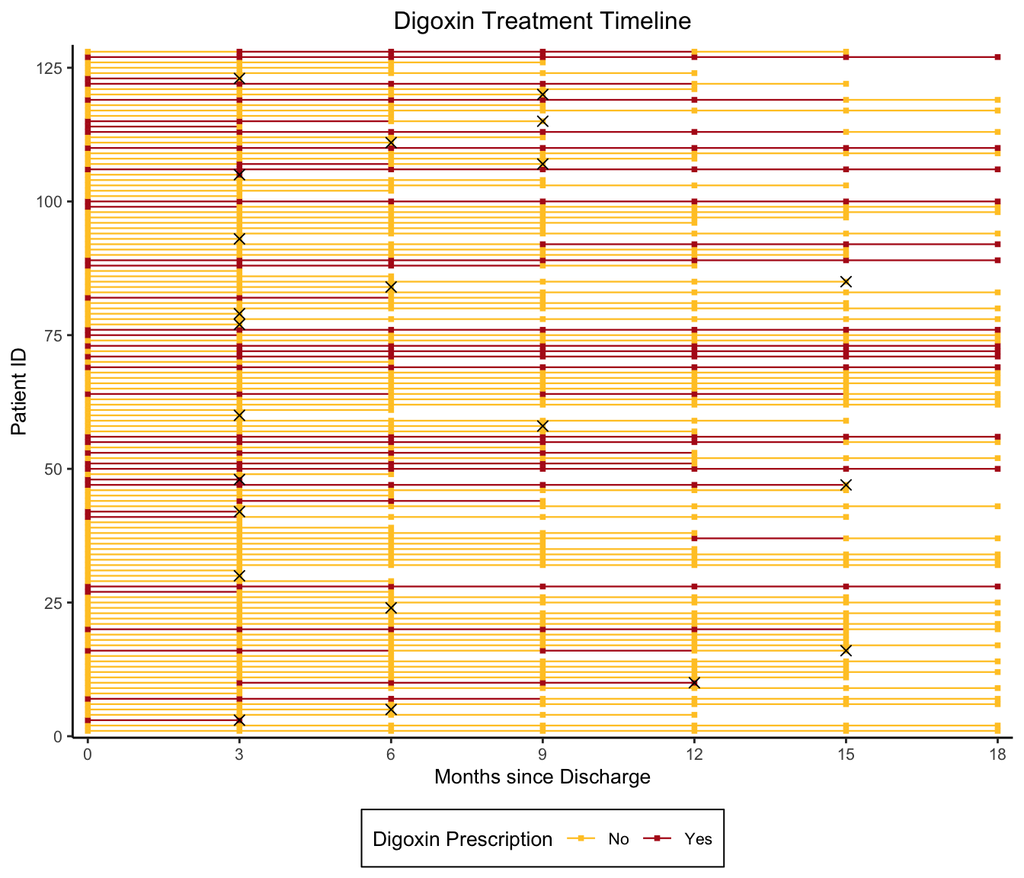

### Time-varying Covariates View

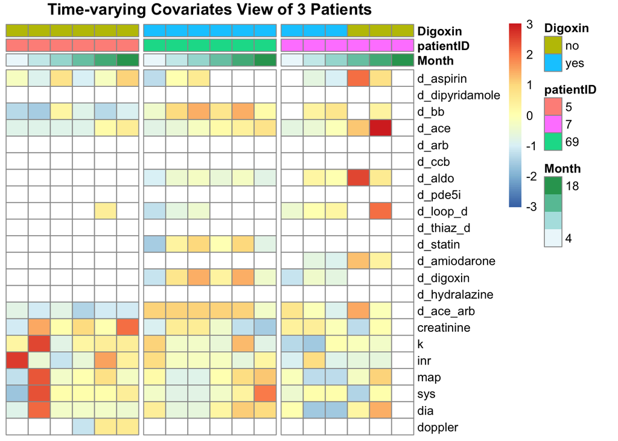

### Baseline Covariates Summary

| **Characteristic** | **DIGOXIN~Never**, N = 85<sup>1</sup> | **DIGOXIN~Yes**, N = 43<sup>1</sup> |
| --- | --- | --- |
| STRATEGY |  |  |
| dt | 62 (73%) | 37 (86%) |
| other | 23 (27%) | 6 (14%) |
| INTERMACS_CLASS |  |  |
| 1 | 8 (9.4%) | 3 (7.0%) |
| 2 | 44 (52%) | 26 (60%) |
| 3 | 31 (36%) | 12 (28%) |
| 4 | 2 (2.4%) | 2 (4.7%) |
| AGE_IMPLANT | 61 (53, 69) | 63 (54, 70) |
| SEX_M_MALE |  |  |
| f | 15 (18%) | 5 (12%) |
| m | 70 (82%) | 38 (88%) |
| HYPERTENSION | 56 (66%) | 30 (70%) |
| HX_AFIB_A_FLUTT | 42 (49%) | 20 (47%) |
| PRIOR_STROKE | 11 (13%) | 3 (7.0%) |
| TYPE2DIABETES_0_NO_1_YES | 33 (39%) | 20 (47%) |
| SMOKING_HISTORY_OR_CURRENT | 44 (52%) | 19 (44%) |
| HGT_M | 1.73 (1.67, 1.80) | 1.78 (1.68, 1.83) |
| WEIGHT_KG | 83 (72, 98) | 85 (72, 94) |
| BMI | 28.1 (24.8, 31.9) | 26.8 (23.9, 31.8) |
| MCS_SUPPORT_PRE_VAD_YES_NO | 37 (44%) | 16 (37%) |
| BYPASS_TIME | 85 (68, 114) | 87 (62, 111) |
| CT_ICU_LOS_POST_VAD | 11 (7, 18) | 10 (7, 13) |
| TOTAL_LOS_INCLUDES | 21 (11, 30) | 19 (14, 34) |
| CREATININE | 1.40 (1.15, 1.73) | 1.36 (1.15, 1.65) |
| BUN | 23 (17, 33) | 24 (18, 34) |
| ALBUMIN_G_D_L | 16.0 (13.0, 21.0) | 17.0 (13.5, 18.5) |
| TBILI | 7.0 (5.0, 13.0) | 7.0 (4.0, 12.0) |
| INR | 1.20 (1.10, 1.30) | 1.20 (1.10, 1.30) |
| SODIUM | 137.0 (135.0, 140.0) | 136.0 (134.0, 139.0) |
| WBC | 7.65 (6.34, 10.09) | 8.09 (6.46, 10.15) |
| PLATELETS | 191 (156, 226) | 164 (134, 197) |
| HEMOGLOBIN | 12.00 (10.10, 13.30) | 11.80 (10.35, 13.20) |
| RACE |  |  |
| afam | 23 (27%) | 7 (16%) |
| other | 62 (73%) | 36 (84%) |
| MAP_DISCHARGE | 79 (73, 86) | 79 (72, 84) |
| SYSTOLIC_BP | 97 (91, 104) | 98 (92, 103) |
| DIASTOLIC_BP | 70 (63, 76) | 71 (61, 74) |
| CREAT_DISCHARGE | 1.13 (0.93, 1.48) | 1.14 (0.90, 1.38) |
| K_DISCHARGE | 4.40 (4.00, 4.70) | 4.50 (4.20, 4.70) |
| INR_DISCHARGE | 2.30 (2.00, 2.70) | 2.40 (2.20, 2.80) |

<sup>*1*</sup> Statistics presented: n (%); median (IQR)

### Time-varying Covariates Summary

**Overall Time-varying Covariates Summary**

| **Characteristic** | **DIGOXIN~Never**, N = 85<sup>1</sup> | **DIGOXIN~Yes**, N = 43<sup>1</sup> |
| --- | --- | --- |
| ASPIRIN | 10.10 (2.60, 14.73) | 9.20 (1.93, 15.68) |
| DIPYRIDAMOLE | 0.00 (0.00, 0.00) | 0.00 (0.00, 0.00) |
| BB | 367.71 (102.92, 629.17) | 339.17 (102.08, 828.33) |
| ACE | 0.00 (0.00, 8.00) | 0.00 (0.00, 35.67) |
| ARB | 0.00 (0.00, 0.00) | 0.00 (0.00, 0.00) |
| CCB | 0.00 (0.00, 21.00) | 0.00 (0.00, 23.88) |
| ALDO | 56.67 (0.00, 269.17) | 0.00 (0.00, 129.06) |
| PDE5I | 0.00 (0.00, 98.50) | 0.00 (0.00, 189.00) |
| LOOP | 150.00 (46.28, 350.67) | 107.33 (14.00, 351.00) |
| THIAZ | 0.00 (0.00, 0.00) | 0.00 (0.00, 0.00) |
| STATIN | 9.33 (0.00, 329.33) | 0.00 (0.00, 296.00) |
| AMIODARONE | 0.00 (0.00, 1,640.00) | 313.33 (0.00, 1,282.12) |
| DIGOXIN | 0.00 (0.00, 320.83) | 0.00 (0.00, 512.50) |
| HYDRALAZINE | 0.00 (0.00, 0.00) | 0.00 (0.00, 0.00) |
| ACE_ARB | 0.00 (0.00, 207.50) | 0.00 (0.00, 554.90) |
| CREATININE | 6.04 (2.95, 8.23) | 5.68 (3.28, 6.78) |
| K | 19.20 (12.20, 25.30) | 18.40 (9.65, 23.95) |
| INR | 9.60 (5.50, 12.90) | 9.00 (4.40, 12.15) |
| MAP | 362.00 (247.67, 487.00) | 357.33 (197.17, 446.17) |
| SYS | 415.00 (300.00, 567.00) | 450.00 (230.50, 526.00) |
| DIA | 316.00 (216.00, 438.00) | 316.00 (184.00, 408.50) |
| DOPPLER | 0.00 (0.00, 0.00) | 0.00 (0.00, 0.00) |

<sup>*1*</sup> Statistics presented: median (IQR)

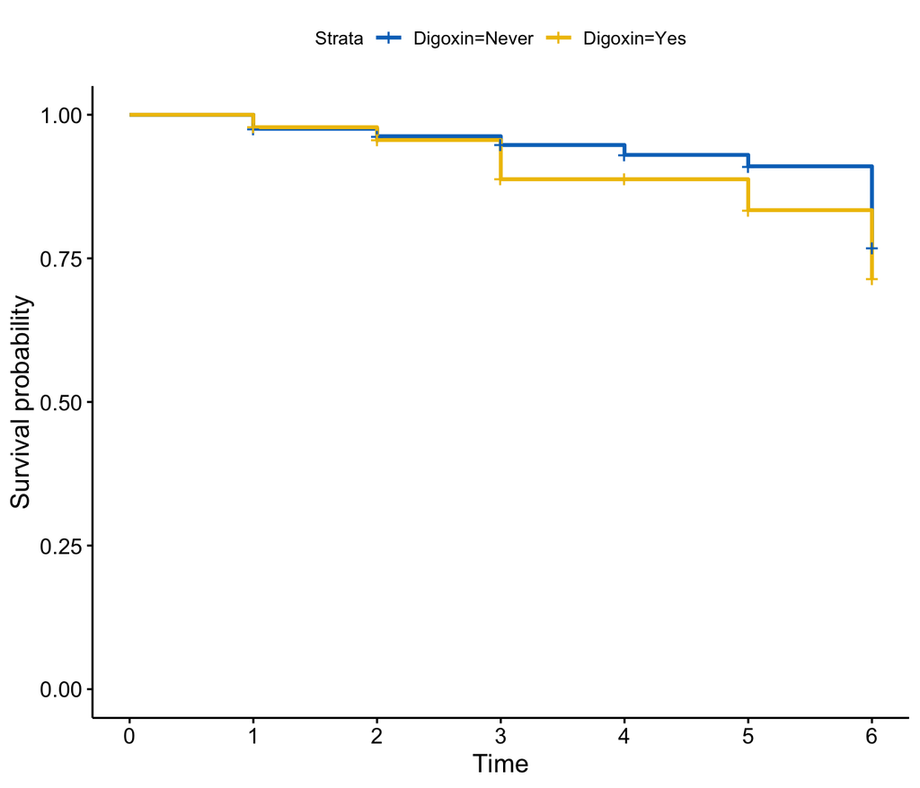

### Unadjusted Cox proportional hazards model

The unadjusted HR of Digoxin was 1.38 (95% CI: 0.6 - 3.2).

### The time-varing Cox proportional hazards model

The HR of time-varing Cox PH model was 1.02 (95% CI: 0.42 - 2.51).

### marginal structural model

The HR of marginal structural model was 1.01 (95% CI: 0.99 - 1.03).

### HR Summary Table

|  | Hazards Ratio | 95% CI | p-Value |
| --- | --- | --- | --- |
| Unadjusted | 1.38 | 0.6-3.2 | 0.45 |
| Time-Varing Cox-PH | 1.02 | 0.42-2.51 | 0.96 |
| Marginal Structural Model | 1.01 | 0.99-1.03 | 0.23 |

## Ace/Arb 18-month censoring / 3-month node

### Ace/Arb Treatment Timeline

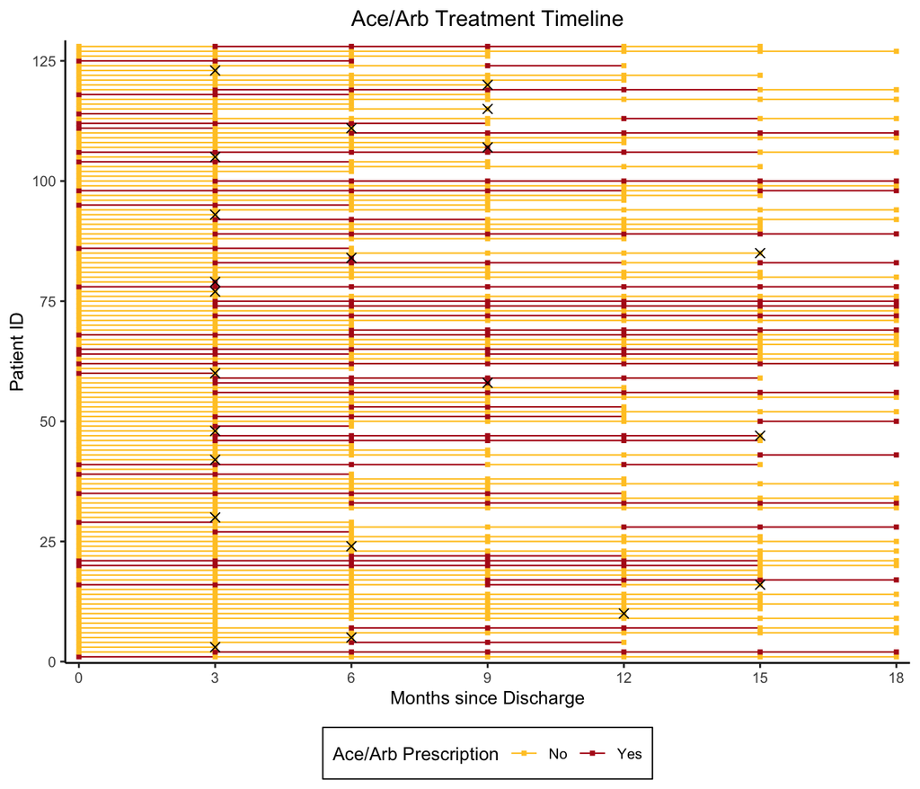

### Time-varying Covariates View

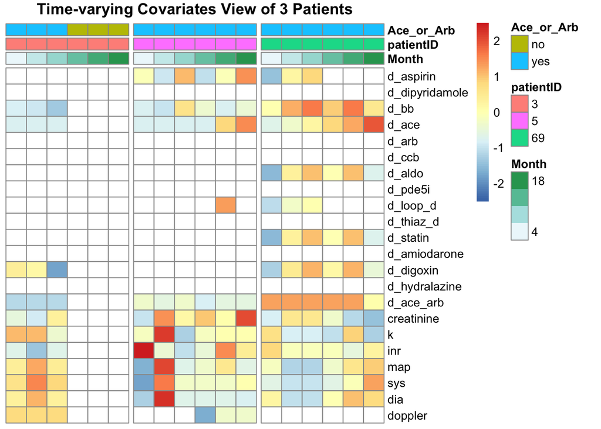

### Baseline Covariates Summary

| **Characteristic** | **Ace/Arb~Never**, N = 68<sup>1</sup> | **Ace/Arb~Yes**, N = 60<sup>1</sup> |
| --- | --- | --- |
| STRATEGY |  |  |
| dt | 49 (72%) | 50 (83%) |
| other | 19 (28%) | 10 (17%) |
| INTERMACS_CLASS |  |  |
| 1 | 6 (8.8%) | 5 (8.3%) |
| 2 | 35 (51%) | 35 (58%) |
| 3 | 24 (35%) | 19 (32%) |
| 4 | 3 (4.4%) | 1 (1.7%) |
| AGE_IMPLANT | 61 (55, 69) | 61 (49, 68) |
| SEX_M_MALE |  |  |
| f | 11 (16%) | 9 (15%) |
| m | 57 (84%) | 51 (85%) |
| HYPERTENSION | 45 (66%) | 41 (68%) |
| HX_AFIB_A_FLUTT | 34 (50%) | 28 (47%) |
| PRIOR_STROKE | 7 (10%) | 7 (12%) |
| TYPE2DIABETES_0_NO_1_YES | 29 (43%) | 24 (40%) |
| SMOKING_HISTORY_OR_CURRENT | 28 (41%) | 35 (58%) |
| HGT_M | 1.73 (1.65, 1.80) | 1.75 (1.68, 1.80) |
| WEIGHT_KG | 82 (73, 98) | 85 (72, 93) |
| BMI | 28.1 (24.5, 32.6) | 27.5 (24.4, 31.7) |
| MCS_SUPPORT_PRE_VAD_YES_NO | 28 (41%) | 25 (42%) |
| BYPASS_TIME | 87 (72, 118) | 86 (62, 107) |
| CT_ICU_LOS_POST_VAD | 10 (7, 19) | 11 (7, 14) |
| TOTAL_LOS_INCLUDES | 18 (11, 29) | 22 (17, 32) |
| CREATININE | 1.39 (1.19, 1.64) | 1.39 (1.13, 1.78) |
| BUN | 23 (17, 34) | 26 (18, 32) |
| ALBUMIN_G_D_L | 16.0 (14.0, 19.0) | 17.0 (13.0, 20.0) |
| TBILI | 7.5 (5.0, 12.0) | 6.0 (4.0, 13.0) |
| INR | 1.20 (1.10, 1.30) | 1.20 (1.10, 1.30) |
| SODIUM | 137.0 (135.0, 140.0) | 137.0 (134.0, 139.0) |
| WBC | 7.92 (6.54, 9.79) | 8.04 (5.97, 10.61) |
| PLATELETS | 180 (139, 216) | 184 (155, 219) |
| HEMOGLOBIN | 12.05 (10.10, 13.30) | 11.80 (10.15, 13.33) |
| RACE |  |  |
| afam | 14 (21%) | 16 (27%) |
| other | 54 (79%) | 44 (73%) |
| MAP_DISCHARGE | 79 (75, 86) | 77 (72, 84) |
| SYSTOLIC_BP | 98 (91, 105) | 97 (90, 103) |
| DIASTOLIC_BP | 71 (65, 76) | 69 (62, 75) |
| CREAT_DISCHARGE | 1.23 (0.94, 1.57) | 1.10 (0.91, 1.35) |
| K_DISCHARGE | 4.40 (4.00, 4.70) | 4.50 (4.10, 4.80) |
| INR_DISCHARGE | 2.30 (2.00, 2.80) | 2.40 (2.20, 2.73) |

<sup>*1*</sup> Statistics presented: n (%); median (IQR)

### Time-varying Covariates Summary

**Overall Time-varying Covariates Summary**

| **Characteristic** | **Ace/Arb~Never**, N = 68<sup>1</sup> | **Ace/Arb~Yes**, N = 60<sup>1</sup> |
| --- | --- | --- |
| ASPIRIN | 11.68 (5.02, 16.56) | 8.28 (2.41, 13.60) |
| DIPYRIDAMOLE | 0.00 (0.00, 0.00) | 0.00 (0.00, 0.00) |
| BB | 418.33 (106.67, 761.56) | 304.58 (93.96, 622.19) |
| ACE | 0.00 (0.00, 13.67) | 0.00 (0.00, 6.96) |
| ARB | 0.00 (0.00, 0.00) | 0.00 (0.00, 0.00) |
| CCB | 0.00 (0.00, 35.00) | 0.00 (0.00, 0.88) |
| ALDO | 0.00 (0.00, 191.67) | 88.75 (0.00, 229.17) |
| PDE5I | 0.00 (0.00, 320.50) | 0.00 (0.00, 71.50) |
| LOOP | 190.79 (25.33, 484.00) | 103.14 (41.66, 282.17) |
| THIAZ | 0.00 (0.00, 0.00) | 0.00 (0.00, 0.00) |
| STATIN | 0.00 (0.00, 335.67) | 4.67 (0.00, 298.50) |
| AMIODARONE | 376.67 (0.00, 2,063.33) | 0.00 (0.00, 1,028.33) |
| DIGOXIN | 0.00 (0.00, 777.17) | 0.00 (0.00, 272.69) |
| HYDRALAZINE | 0.00 (0.00, 0.00) | 0.00 (0.00, 0.00) |
| ACE_ARB | 0.00 (0.00, 1,009.46) | 0.00 (0.00, 215.83) |
| CREATININE | 6.11 (3.20, 8.01) | 5.45 (2.60, 6.75) |
| K | 19.70 (12.90, 25.02) | 18.60 (8.85, 24.30) |
| INR | 10.21 (5.58, 12.90) | 8.35 (4.80, 12.22) |
| MAP | 362.33 (258.58, 487.92) | 359.67 (184.50, 474.92) |
| SYS | 434.00 (305.75, 565.50) | 428.50 (220.75, 551.25) |
| DIA | 325.50 (228.75, 446.25) | 314.50 (170.25, 416.50) |
| DOPPLER | 0.00 (0.00, 0.00) | 0.00 (0.00, 0.00) |

<sup>*1*</sup> Statistics presented: median (IQR)

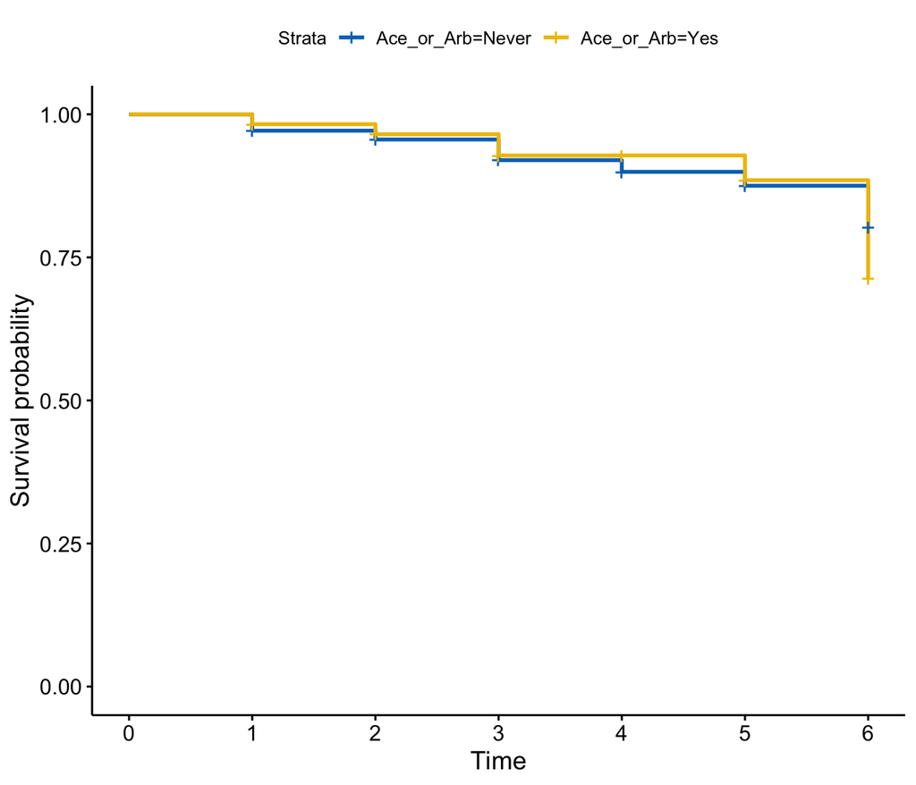

### Unadjusted Cox proportional hazards model

The unadjusted HR of Ace/Arb was 1.28 (95% CI: 0.54 - 3).

### The time-varing Cox proportional hazards model

The HR of time-varing Cox PH model was 1.25 (95% CI: 0.54 - 2.88).

### marginal structural model

The HR of marginal structural model was 0.95 (95% CI: 0.94 - 0.96).

### HR Summary Table

|  | Hazards Ratio | 95% CI | p-Value |
| --- | --- | --- | --- |
| Unadjusted | 1.28 | 0.54-3 | 0.57 |
| Time-Varing Cox-PH | 1.25 | 0.54-2.88 | 0.6 |
| Marginal Structural Model | 0.95 | 0.94-0.96 | 0 |

## Pde5i 18-month censoring / 3-month node

### pde5i Treatment Timeline

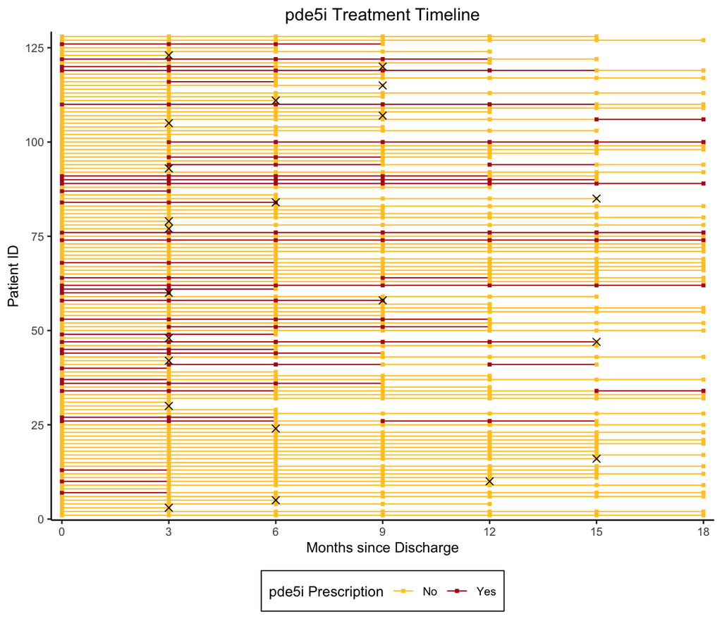

### Time-varying Covariates View

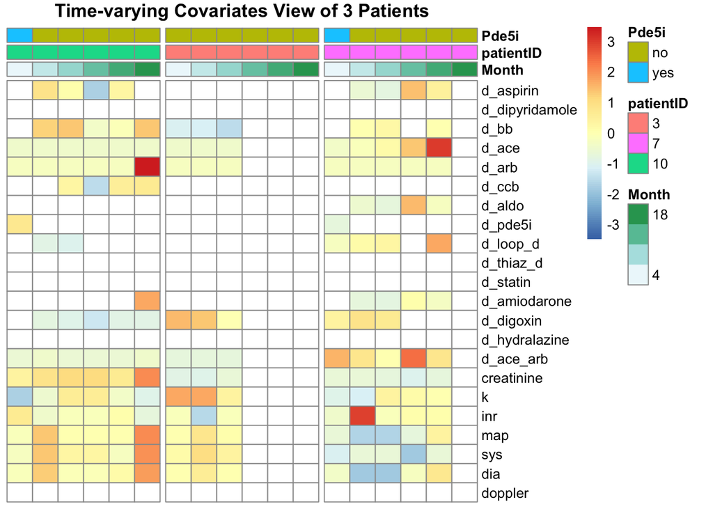

### Baseline Covariates Summary

| **Characteristic** | **Pde5i~Never**, N = 89<sup>1</sup> | **Pde5i~Yes**, N = 39<sup>1</sup> |
| --- | --- | --- |
| STRATEGY |  |  |
| dt | 67 (75%) | 32 (82%) |
| other | 22 (25%) | 7 (18%) |
| INTERMACS_CLASS |  |  |
| 1 | 8 (9.0%) | 3 (7.7%) |
| 2 | 44 (49%) | 26 (67%) |
| 3 | 34 (38%) | 9 (23%) |
| 4 | 3 (3.4%) | 1 (2.6%) |
| AGE_IMPLANT | 61 (53, 70) | 61 (53, 67) |
| SEX_M_MALE |  |  |
| f | 11 (12%) | 9 (23%) |
| m | 78 (88%) | 30 (77%) |
| HYPERTENSION | 57 (64%) | 29 (74%) |
| HX_AFIB_A_FLUTT | 44 (49%) | 18 (46%) |
| PRIOR_STROKE | 7 (7.9%) | 7 (18%) |
| TYPE2DIABETES_0_NO_1_YES | 33 (37%) | 20 (51%) |
| SMOKING_HISTORY_OR_CURRENT | 44 (49%) | 19 (49%) |
| HGT_M | 1.75 (1.68, 1.80) | 1.73 (1.64, 1.80) |
| WEIGHT_KG | 83 (72, 97) | 85 (71, 95) |
| BMI | 27.7 (24.2, 31.7) | 28.5 (26.2, 32.6) |
| MCS_SUPPORT_PRE_VAD_YES_NO | 33 (37%) | 20 (51%) |
| BYPASS_TIME | 86 (68, 117) | 86 (64, 106) |
| CT_ICU_LOS_POST_VAD | 10 (7, 14) | 12 (9, 18) |
| TOTAL_LOS_INCLUDES | 19 (10, 29) | 21 (18, 35) |
| CREATININE | 1.34 (1.13, 1.70) | 1.45 (1.22, 1.73) |
| BUN | 23 (16, 32) | 27 (20, 34) |
| ALBUMIN_G_D_L | 16.0 (13.0, 20.0) | 17.0 (13.5, 18.5) |
| TBILI | 7.0 (5.0, 13.0) | 6.0 (4.0, 11.5) |
| INR | 1.20 (1.10, 1.30) | 1.20 (1.10, 1.30) |
| SODIUM | 137.0 (135.0, 140.0) | 136.0 (134.0, 138.0) |
| WBC | 7.60 (6.39, 9.87) | 9.23 (6.43, 11.32) |
| PLATELETS | 178 (146, 214) | 191 (148, 232) |
| HEMOGLOBIN | 12.00 (10.40, 13.30) | 11.70 (9.95, 13.35) |
| RACE |  |  |
| afam | 16 (18%) | 14 (36%) |
| other | 73 (82%) | 25 (64%) |
| MAP_DISCHARGE | 77 (72, 85) | 80 (76, 88) |
| SYSTOLIC_BP | 97 (90, 102) | 98 (93, 108) |
| DIASTOLIC_BP | 69 (62, 74) | 72 (64, 78) |
| CREAT_DISCHARGE | 1.12 (0.92, 1.44) | 1.21 (0.94, 1.53) |
| K_DISCHARGE | 4.50 (4.00, 4.80) | 4.40 (4.15, 4.60) |
| INR_DISCHARGE | 2.40 (2.00, 2.80) | 2.30 (2.10, 2.70) |

<sup>*1*</sup> Statistics presented: n (%); median (IQR)

### Time-varying Covariates Summary

**Overall Time-varying Covariates Summary**

| **Characteristic** | **Pde5i~Never**, N = 89<sup>1</sup> | **Pde5i~Yes**, N = 39<sup>1</sup> |
| --- | --- | --- |
| ASPIRIN | 11.47 (4.20, 16.63) | 8.33 (1.73, 12.07) |
| DIPYRIDAMOLE | 0.00 (0.00, 0.00) | 0.00 (0.00, 0.00) |
| BB | 371.67 (102.92, 742.08) | 289.17 (103.75, 652.50) |
| ACE | 0.00 (0.00, 10.50) | 0.00 (0.00, 8.46) |
| ARB | 0.00 (0.00, 0.00) | 0.00 (0.00, 0.00) |
| CCB | 0.00 (0.00, 22.33) | 0.00 (0.00, 18.67) |
| ALDO | 52.50 (0.00, 215.83) | 10.83 (0.00, 172.12) |
| PDE5I | 0.00 (0.00, 126.00) | 0.00 (0.00, 88.00) |
| LOOP | 130.47 (28.00, 383.33) | 112.00 (40.43, 296.33) |
| THIAZ | 0.00 (0.00, 0.00) | 0.00 (0.00, 0.00) |
| STATIN | 0.00 (0.00, 302.00) | 82.00 (0.00, 340.00) |
| AMIODARONE | 46.67 (0.00, 1,640.00) | 273.33 (0.00, 1,331.67) |
| DIGOXIN | 0.00 (0.00, 320.83) | 0.00 (0.00, 393.75) |
| HYDRALAZINE | 0.00 (0.00, 0.00) | 0.00 (0.00, 0.00) |
| ACE_ARB | 0.00 (0.00, 1,108.33) | 0.00 (0.00, 158.25) |
| CREATININE | 6.10 (3.34, 7.98) | 4.99 (2.70, 6.31) |
| K | 21.30 (12.20, 25.70) | 16.60 (12.00, 20.10) |
| INR | 10.99 (5.53, 13.10) | 6.42 (4.95, 9.40) |
| MAP | 389.00 (236.00, 509.67) | 322.67 (250.50, 393.33) |
| SYS | 455.00 (278.00, 588.00) | 405.00 (294.50, 469.00) |
| DIA | 353.00 (211.00, 466.00) | 279.00 (216.00, 357.00) |
| DOPPLER | 0.00 (0.00, 0.00) | 0.00 (0.00, 0.00) |

<sup>*1*</sup> Statistics presented: median (IQR)

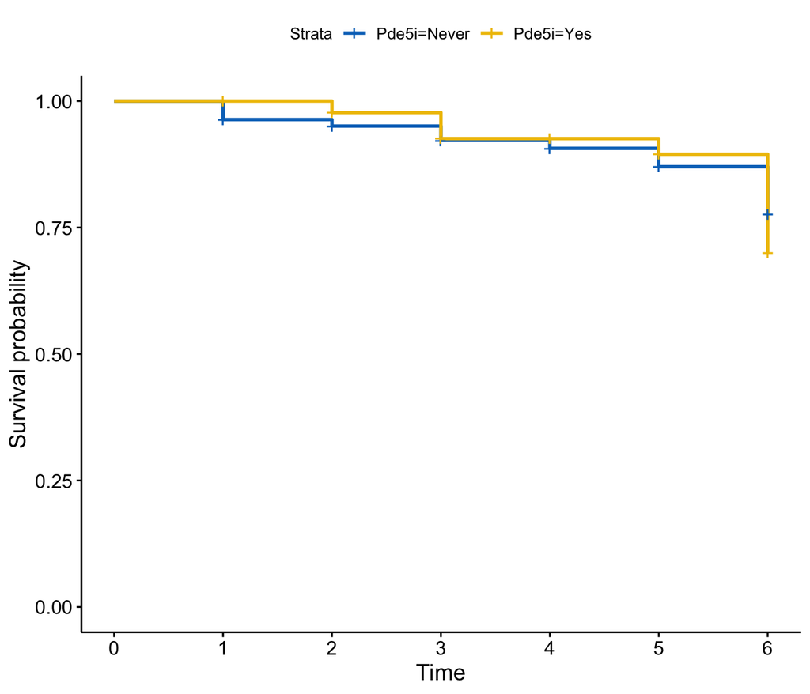

### Unadjusted Cox proportional hazards model

The unadjusted HR of Pde5i was 1.19 (95% CI: 0.51 - 2.79).

### The time-varing Cox proportional hazards model

The HR of time-varing Cox PH model was 1.3 (95% CI: 0.53 - 3.2).

### marginal structural model

The HR of marginal structural model was 1.01 (95% CI: 1 - 1.03).

### HR Summary Table

|  | Hazards Ratio | 95% CI | p-Value |
| --- | --- | --- | --- |
| Unadjusted | 1.19 | 0.51-2.79 | 0.69 |
| Time-Varing Cox-PH | 1.3 | 0.53-3.2 | 0.57 |
| Marginal Structural Model | 1.01 | 1-1.03 | 0.14 |

## Appendix

### Digoxin Per-node Time-varying Covariates Summary

| **Characteristic** | **DIGOXIN~Never**, N = 85<sup>1</sup> | **DIGOXIN~Yes**, N = 43<sup>1</sup> |
| --- | --- | --- |
| ASPIRIN_1 | 2.00 (0.47, 2.57) | 1.90 (1.32, 2.42) |
| ASPIRIN_2 | 2.33 (0.00, 3.10) | 2.10 (0.00, 3.05) |
| ASPIRIN_3 | 2.53 (0.00, 3.27) | 0.00 (0.00, 2.95) |
| ASPIRIN_4 | 1.30 (0.00, 2.57) | 1.40 (0.00, 2.80) |
| ASPIRIN_5 | 0.00 (0.00, 2.57) | 0.00 (0.00, 2.87) |
| ASPIRIN_6 | 0.00 (0.00, 1.87) | 0.00 (0.00, 1.05) |
| DIPYRIDAMOLE_1 | 0.00 (0.00, 0.00) | 0.00 (0.00, 0.00) |
| DIPYRIDAMOLE_2 | 0.00 (0.00, 0.00) | 0.00 (0.00, 0.00) |
| DIPYRIDAMOLE_3 | 0.00 (0.00, 0.00) | 0.00 (0.00, 0.00) |
| DIPYRIDAMOLE_4 | 0.00 (0.00, 0.00) | 0.00 (0.00, 0.00) |
| DIPYRIDAMOLE_5 | 0.00 (0.00, 0.00) | 0.00 (0.00, 0.00) |
| DIPYRIDAMOLE_6 | 0.00 (0.00, 0.00) | 0.00 (0.00, 0.00) |
| BB_1 | 40.83 (0.00, 120.00) | 46.67 (6.67, 94.58) |
| BB_2 | 58.33 (7.92, 142.50) | 65.00 (0.00, 166.67) |
| BB_3 | 78.33 (0.00, 163.33) | 40.83 (0.00, 128.33) |
| BB_4 | 46.67 (0.00, 140.00) | 52.50 (0.00, 129.17) |
| BB_5 | 0.00 (0.00, 105.00) | 0.00 (0.00, 70.00) |
| BB_6 | 0.00 (0.00, 70.00) | 0.00 (0.00, 13.12) |
| ACE_1 | 0.00 (0.00, 0.00) | 0.00 (0.00, 0.42) |
| ACE_2 | 0.00 (0.00, 0.00) | 0.00 (0.00, 0.00) |
| ACE_3 | 0.00 (0.00, 0.00) | 0.00 (0.00, 0.00) |
| ACE_4 | 0.00 (0.00, 0.00) | 0.00 (0.00, 0.00) |
| ACE_5 | 0.00 (0.00, 0.00) | 0.00 (0.00, 0.00) |
| ACE_6 | 0.00 (0.00, 0.00) | 0.00 (0.00, 0.00) |
| ARB_1 | 0.00 (0.00, 0.00) | 0.00 (0.00, 0.00) |
| ARB_2 | 0.00 (0.00, 0.00) | 0.00 (0.00, 0.00) |
| ARB_3 | 0.00 (0.00, 0.00) | 0.00 (0.00, 0.00) |
| ARB_4 | 0.00 (0.00, 0.00) | 0.00 (0.00, 0.00) |
| ARB_5 | 0.00 (0.00, 0.00) | 0.00 (0.00, 0.00) |
| ARB_6 | 0.00 (0.00, 0.00) | 0.00 (0.00, 0.00) |

[output cut: 102 more lines]

<sup>*1*</sup> Statistics presented: median (IQR)

### Ace/Arb Per-node Time-varying Covariates Summary

| **Characteristic** | **Ace/Arb~Never**, N = 68<sup>1</sup> | **Ace/Arb~Yes**, N = 60<sup>1</sup> |
| --- | --- | --- |
| ASPIRIN_1 | 1.98 (0.00, 2.61) | 1.90 (1.38, 2.35) |
| ASPIRIN_2 | 2.32 (0.00, 3.03) | 2.33 (0.00, 3.19) |
| ASPIRIN_3 | 2.57 (0.00, 3.22) | 1.63 (0.00, 3.03) |
| ASPIRIN_4 | 2.10 (0.00, 3.03) | 0.00 (0.00, 2.02) |
| ASPIRIN_5 | 0.00 (0.00, 2.80) | 0.00 (0.00, 2.18) |
| ASPIRIN_6 | 0.00 (0.00, 2.33) | 0.00 (0.00, 0.00) |
| DIPYRIDAMOLE_1 | 0.00 (0.00, 0.00) | 0.00 (0.00, 0.00) |
| DIPYRIDAMOLE_2 | 0.00 (0.00, 0.00) | 0.00 (0.00, 0.00) |
| DIPYRIDAMOLE_3 | 0.00 (0.00, 0.00) | 0.00 (0.00, 0.00) |
| DIPYRIDAMOLE_4 | 0.00 (0.00, 0.00) | 0.00 (0.00, 0.00) |
| DIPYRIDAMOLE_5 | 0.00 (0.00, 0.00) | 0.00 (0.00, 0.00) |
| DIPYRIDAMOLE_6 | 0.00 (0.00, 0.00) | 0.00 (0.00, 0.00) |
| BB_1 | 39.08 (0.00, 124.38) | 44.17 (0.00, 82.50) |
| BB_2 | 58.65 (7.81, 162.08) | 61.25 (0.00, 140.62) |
| BB_3 | 84.58 (0.00, 156.25) | 46.25 (0.00, 142.92) |
| BB_4 | 55.42 (0.00, 142.92) | 46.67 (0.00, 97.50) |
| BB_5 | 0.00 (0.00, 105.00) | 0.00 (0.00, 75.83) |
| BB_6 | 0.00 (0.00, 34.17) | 0.00 (0.00, 70.00) |
| ACE_1 | 0.00 (0.00, 1.83) | 0.00 (0.00, 0.00) |
| ACE_2 | 0.00 (0.00, 1.17) | 0.00 (0.00, 0.00) |
| ACE_3 | 0.00 (0.00, 0.00) | 0.00 (0.00, 0.00) |
| ACE_4 | 0.00 (0.00, 0.00) | 0.00 (0.00, 0.00) |
| ACE_5 | 0.00 (0.00, 0.00) | 0.00 (0.00, 0.00) |
| ACE_6 | 0.00 (0.00, 0.00) | 0.00 (0.00, 0.00) |
| ARB_1 | 0.00 (0.00, 0.00) | 0.00 (0.00, 0.00) |
| ARB_2 | 0.00 (0.00, 0.00) | 0.00 (0.00, 0.00) |
| ARB_3 | 0.00 (0.00, 0.00) | 0.00 (0.00, 0.00) |
| ARB_4 | 0.00 (0.00, 0.00) | 0.00 (0.00, 0.00) |
| ARB_5 | 0.00 (0.00, 0.00) | 0.00 (0.00, 0.00) |
| ARB_6 | 0.00 (0.00, 0.00) | 0.00 (0.00, 0.00) |

[output cut: 102 more lines]

<sup>*1*</sup> Statistics presented: median (IQR)

### Pde5i Per-node Time-varying Covariates Summary

| **Characteristic** | **Pde5i~Never**, N = 89<sup>1</sup> | **Pde5i~Yes**, N = 39<sup>1</sup> |
| --- | --- | --- |
| ASPIRIN_1 | 2.10 (1.47, 2.57) | 1.63 (0.00, 2.35) |
| ASPIRIN_2 | 2.33 (1.30, 3.10) | 2.20 (0.00, 3.05) |
| ASPIRIN_3 | 2.53 (0.00, 3.13) | 0.00 (0.00, 3.05) |
| ASPIRIN_4 | 1.40 (0.00, 2.80) | 0.00 (0.00, 2.10) |
| ASPIRIN_5 | 0.00 (0.00, 2.80) | 0.00 (0.00, 1.63) |
| ASPIRIN_6 | 0.00 (0.00, 2.60) | 0.00 (0.00, 0.00) |
| DIPYRIDAMOLE_1 | 0.00 (0.00, 0.00) | 0.00 (0.00, 0.00) |
| DIPYRIDAMOLE_2 | 0.00 (0.00, 0.00) | 0.00 (0.00, 0.00) |
| DIPYRIDAMOLE_3 | 0.00 (0.00, 0.00) | 0.00 (0.00, 0.00) |
| DIPYRIDAMOLE_4 | 0.00 (0.00, 0.00) | 0.00 (0.00, 0.00) |
| DIPYRIDAMOLE_5 | 0.00 (0.00, 0.00) | 0.00 (0.00, 0.00) |
| DIPYRIDAMOLE_6 | 0.00 (0.00, 0.00) | 0.00 (0.00, 0.00) |
| BB_1 | 46.67 (0.00, 98.33) | 32.50 (0.00, 106.67) |
| BB_2 | 64.17 (7.50, 140.00) | 54.17 (5.83, 169.17) |
| BB_3 | 73.33 (0.00, 145.00) | 51.67 (0.00, 161.67) |
| BB_4 | 46.67 (0.00, 140.00) | 52.50 (0.00, 122.50) |
| BB_5 | 0.00 (0.00, 105.00) | 0.00 (0.00, 42.29) |
| BB_6 | 0.00 (0.00, 90.00) | 0.00 (0.00, 0.00) |
| ACE_1 | 0.00 (0.00, 0.00) | 0.00 (0.00, 0.00) |
| ACE_2 | 0.00 (0.00, 0.00) | 0.00 (0.00, 0.00) |
| ACE_3 | 0.00 (0.00, 0.00) | 0.00 (0.00, 0.00) |
| ACE_4 | 0.00 (0.00, 0.00) | 0.00 (0.00, 0.00) |
| ACE_5 | 0.00 (0.00, 0.00) | 0.00 (0.00, 0.00) |
| ACE_6 | 0.00 (0.00, 0.00) | 0.00 (0.00, 0.00) |
| ARB_1 | 0.00 (0.00, 0.00) | 0.00 (0.00, 0.00) |
| ARB_2 | 0.00 (0.00, 0.00) | 0.00 (0.00, 0.00) |
| ARB_3 | 0.00 (0.00, 0.00) | 0.00 (0.00, 0.00) |
| ARB_4 | 0.00 (0.00, 0.00) | 0.00 (0.00, 0.00) |
| ARB_5 | 0.00 (0.00, 0.00) | 0.00 (0.00, 0.00) |
| ARB_6 | 0.00 (0.00, 0.00) | 0.00 (0.00, 0.00) |

[output cut: 102 more lines]

<sup>*1*</sup> Statistics presented: median (IQR)